# Formative Exercise 03: Data Visualisation

Generate the plots below showing the distribution of dog weight by breed.

## Violin Plot

Make a violin plot with `breed` on the x-axis and `weight` on the y-axis. Make each breed white, 50% transparent, and outlined in a different colour, but omit the legend.

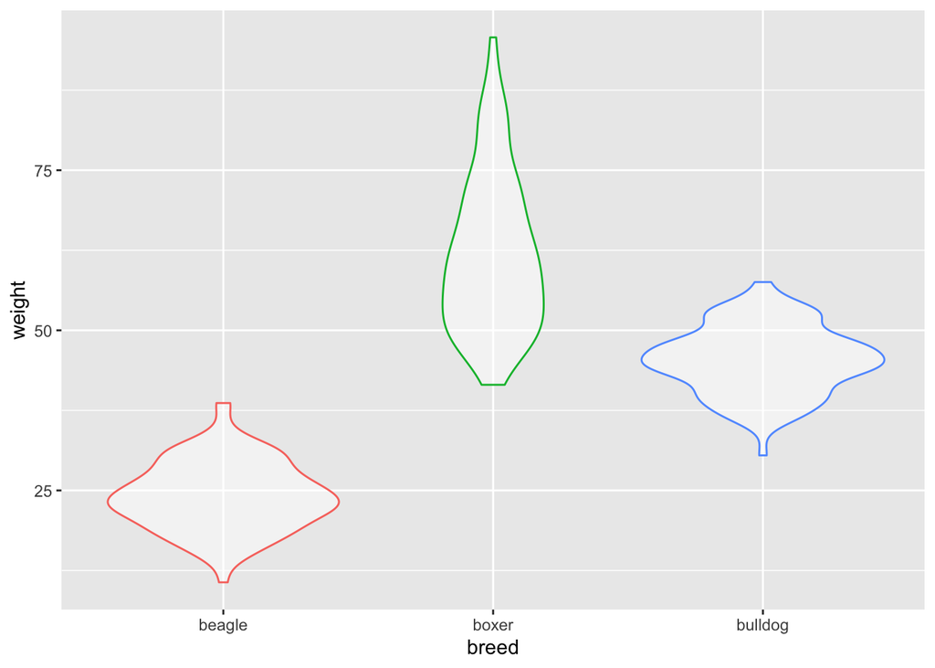

## Boxplot

Make a boxplot with `breed` on the x-axis and `weight` on the y-axis. Make each breed white, 50% transparent, and outlined in a different colour, but omit the legend.

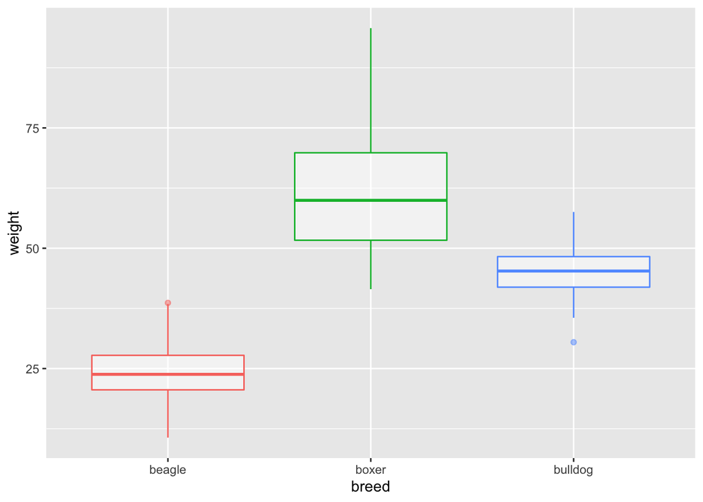

## Density plot

Make a density plot with `weight` on the x-axis. Make each breed white, 50% transparent, and outlined in a different colour, but omit the legend.

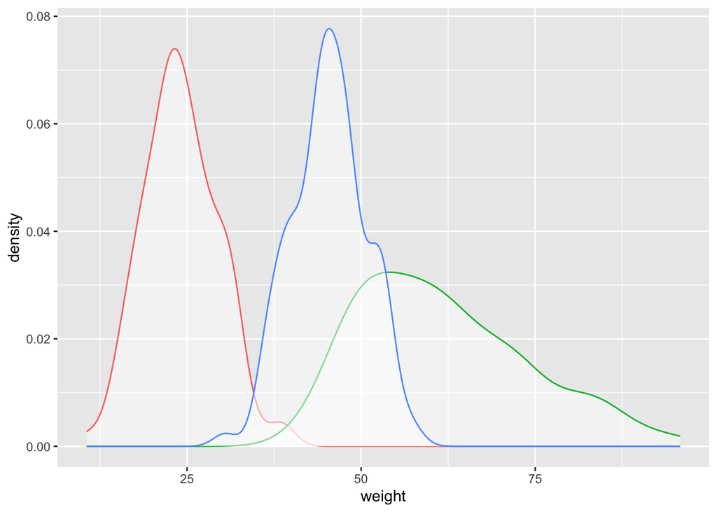

## Column Plot

Use `stat_summary` to create a column plot with `breed` on the x-axis and `weight` on the y-axis and error bars showing 1 standard error. Make each breed white, 50% transparent, and outlined in a different colour, but have the error bars be black. Omit the legend.

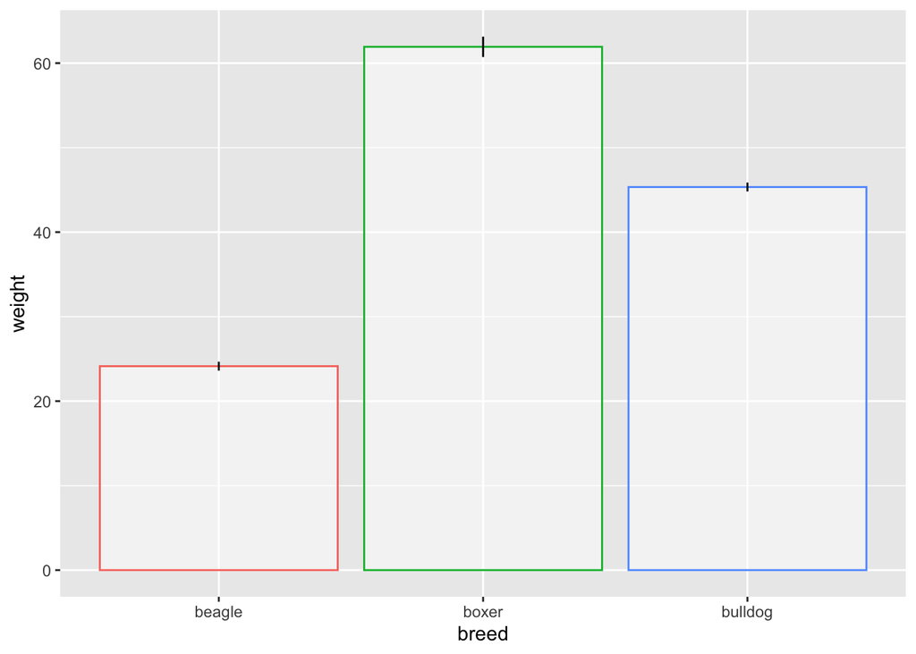

## Grid

Create a grid of the violin plot, boxplot, and column plot above with all three plots on the same row. Make the figure 8 inches wide, 4 inches tall, and the image cover 100% of the width of the markdown output.

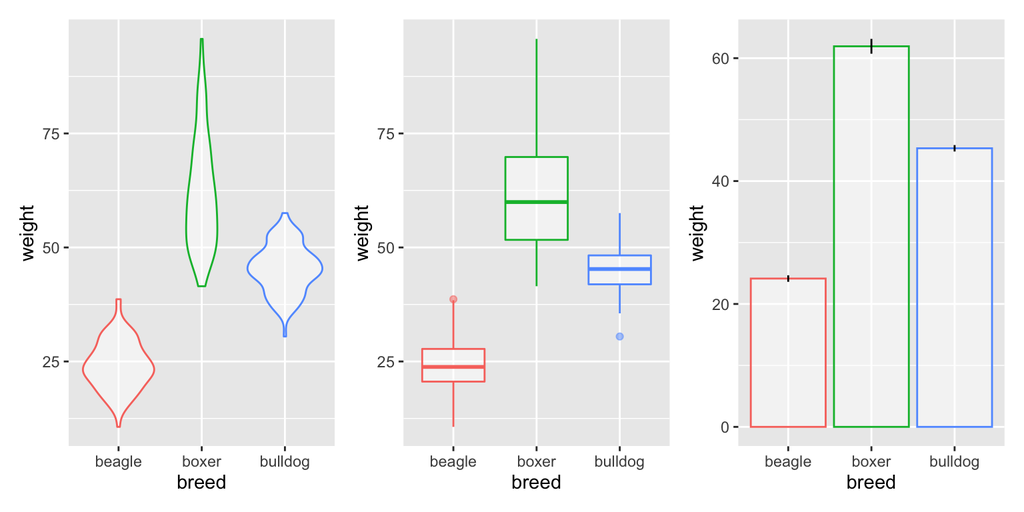

## Changing defaults

For the four plots above, change the axis labels so the x-axis reads “Breed of Dog” or “Weight of Dog” (depending on the plot type) and the y-axis reads “Weight of Dog”, “Number of Dogs”, or “Density of Dogs” (depending on the plot type).

Change the default colours to “orange”, “dodgerblue”, and “hotpink”.

Add a title to each plot describing the plot type.

Save each plot as a PNG file with the names “dog_violin.png”, “dog_boxplot.png”, “dog_density.png”, and “dog_column.png” (the names are important so they show up in the code below).

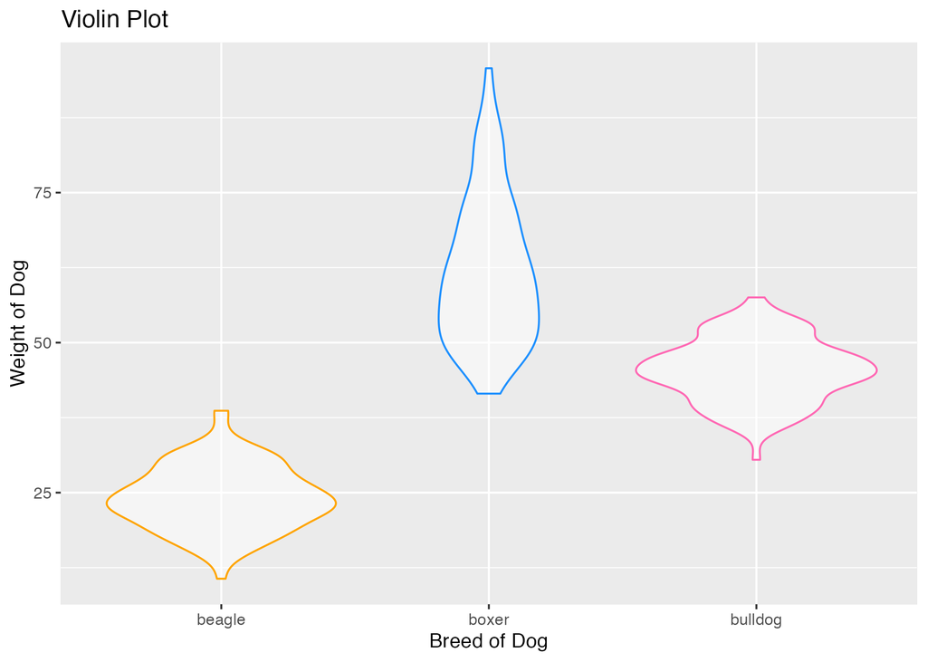

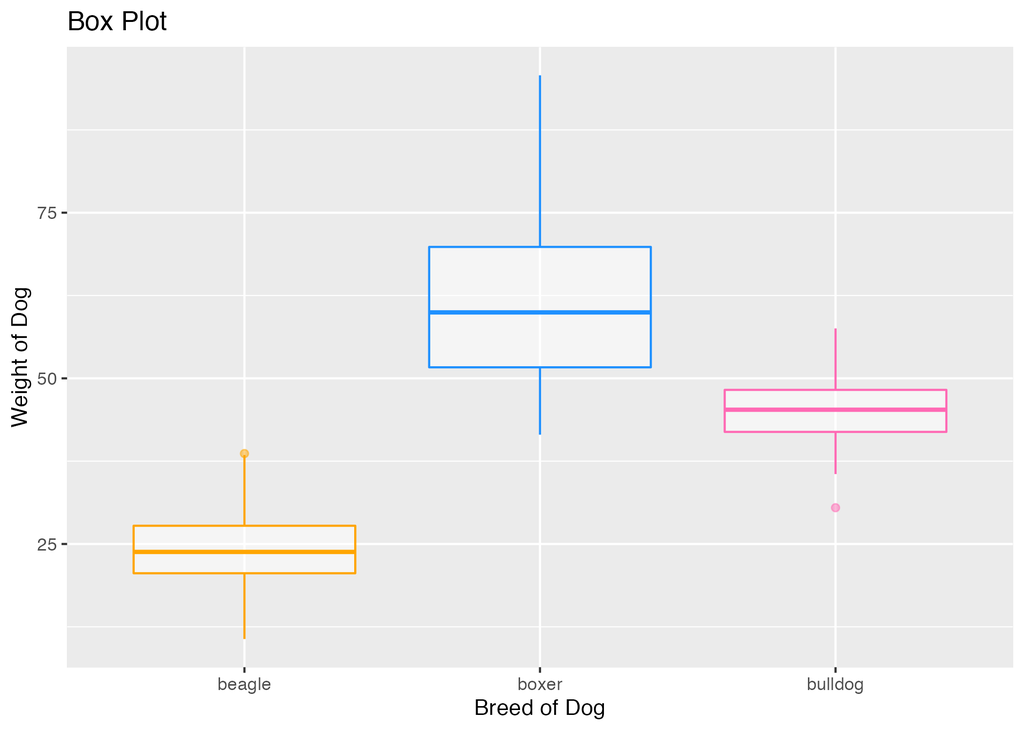

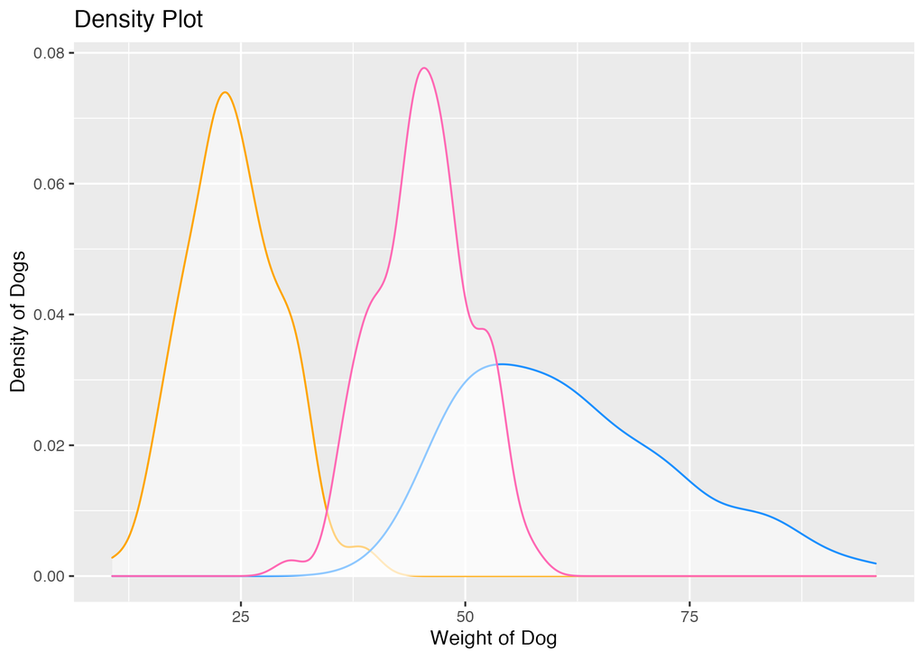

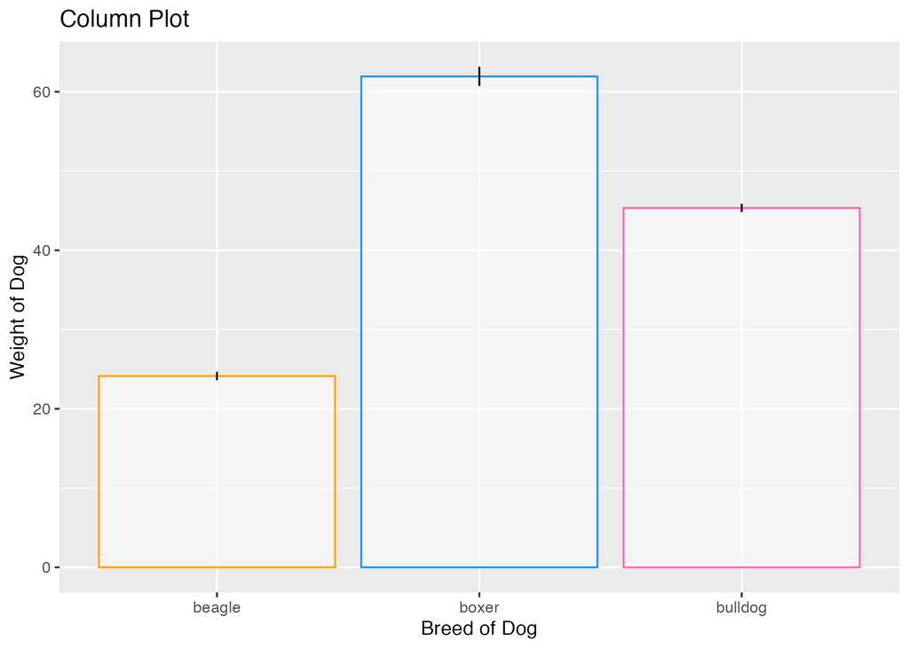

## Line plot

Represent the relationships among disgust subscales from the dataset [reprores::disgust_scores](https://psyteachr.github.io/reprores/data/disgust_scores.csv).

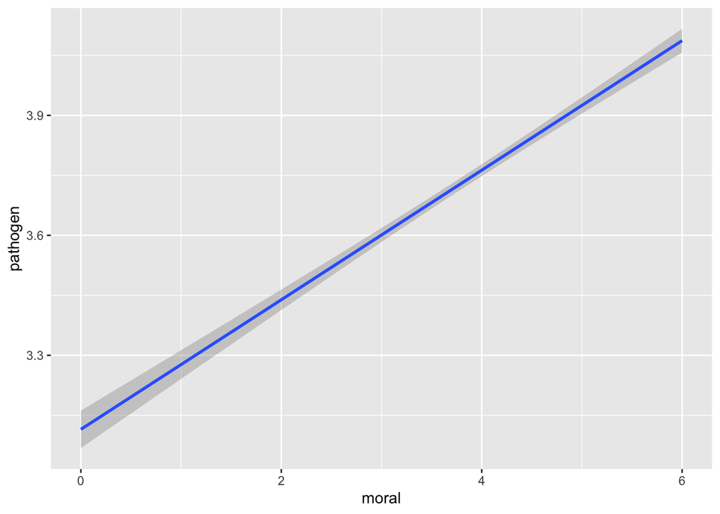

## 2D Density plot

If you add `geom_point()` to the plot above, you’ll see that there is too much data for this visualisation to make sense. Instead, create a 2d density plot of the relationship between moral and pathogen disgust for `disgust_scores`.

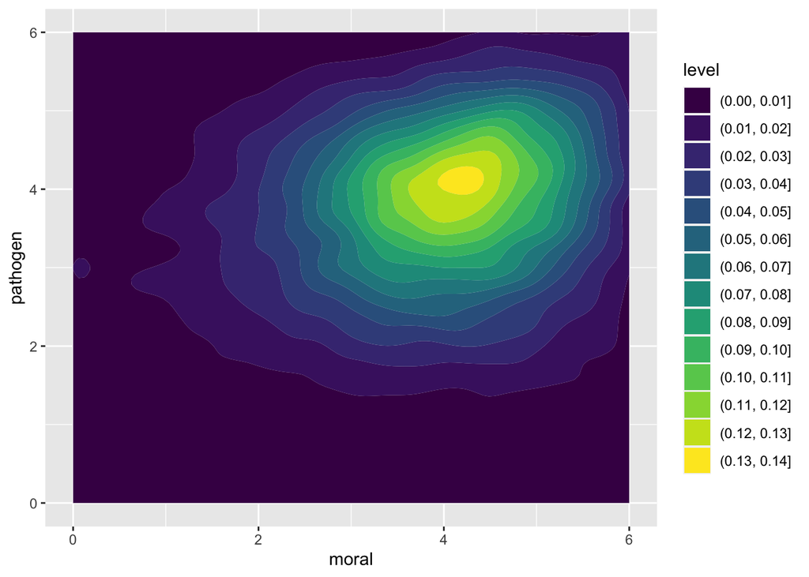

## Many correlated variables

Create a heatmap of the relationships among all the questions in [reprores::disgust_cors](https://psyteachr.github.io/reprores/data/disgust_cors.csv). The correlations have already been calculated for you.

*Bonus*: Figure out how to rotate the text on the x-axis so it’s readable.

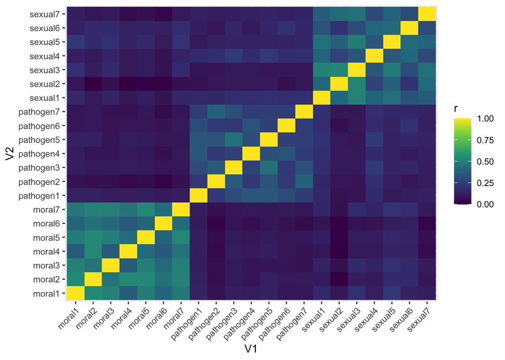

## Facets

Create a grid of plots for the [reprores::stroop](https://psyteachr.github.io/reprores/data/stroop.csv) dataset using faceting.

Plot `rt` for each combination of `word` and `ink` to make a 5x5 grid of density plots. Make each plot line the same colour as the ink. For bonus points, make the lines for plots where the ink colour matches the word colour thicker than the other lines.

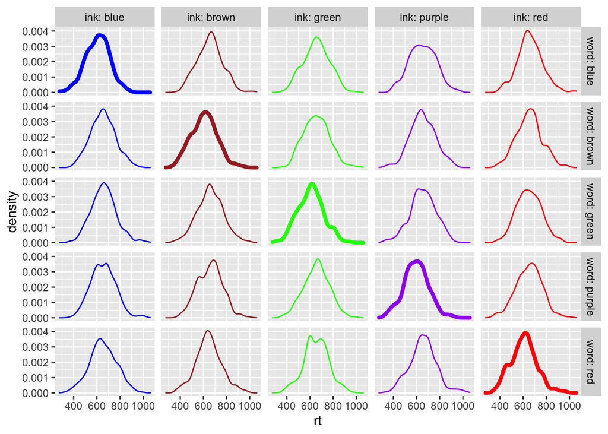

## Advanced Grid

Create a 3x3 grid of linear line plots from `disgust_scores` with columns representing the x-axis and rows representing the y-axis and assign it to `disgust_grid`. Put a density plot of each variable along the diagonal. Make sure the graphs have appropriate titles and axis labels and that the range of the axes are the same in all graphs.

|  | moral | sexual | pathogen |
| --- | --- | --- | --- |
| **moral** | density | line | line |
| **sexual** | line | density | line |
| **pathogen** | line | line | density |

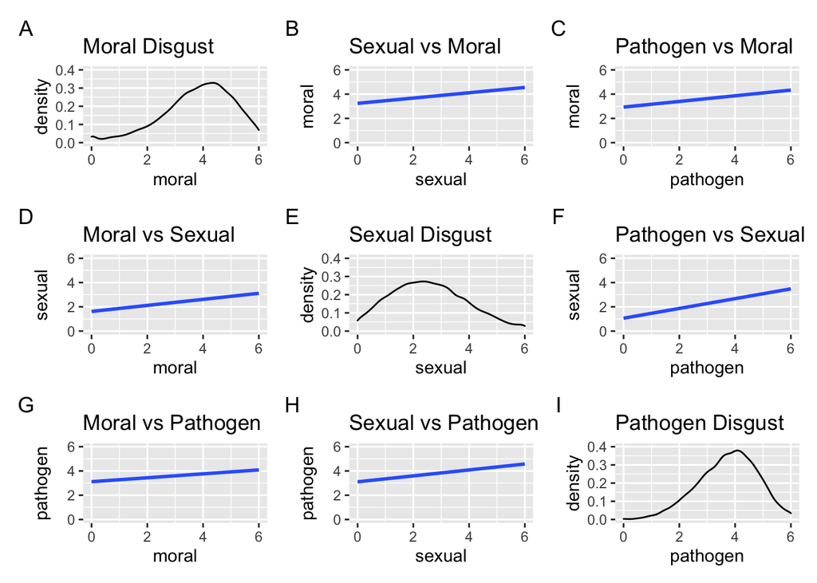